# Descriptive analysis

## Reading packages and sample information

```r
suppressMessages(suppressWarnings(library(dplyr)))
suppressMessages(suppressWarnings(library(ggplot2)))

listGeuvadis = read.table('/raid/genevol/heritability/samples.txt',header = F)
colnames(listGeuvadis) = "samples"
# informacao de expressao
hlaExp = readr::read_tsv("/raid/genevol/heritability/hla_expression.tsv") %>% rename(sampleid = subject_id) %>% filter(sampleid %in% listGeuvadis$samples)
pops = hlaExp %>%  distinct(sampleid , pop)
```

## Relation between fixed effects (lab and sex)

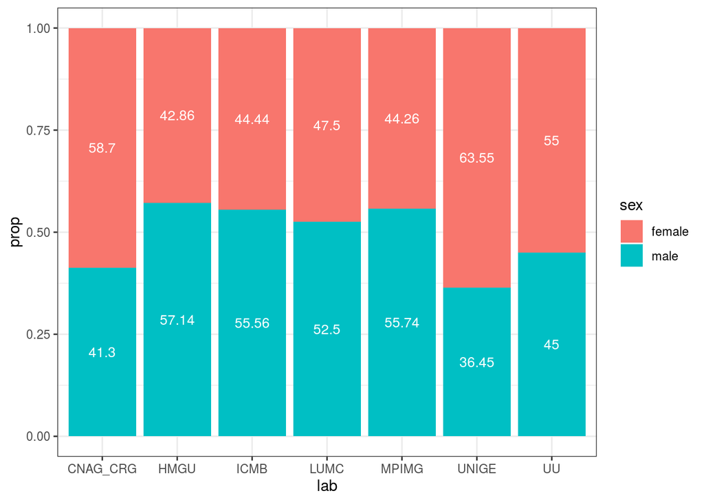

```r
dataTot = hlaExp %>% filter(gene_name == 'HLA-A')
dataPltSL = merge(
    suppressMessages(dataTot %>% group_by( lab , sex ) %>% summarise ( n = n ( ) ))
    ,
    suppressMessages(dataTot %>% group_by( lab ) %>% summarise ( nTot = n ( ) ))
) %>% mutate ( prop = n / nTot )

dataPltSL %>% ggplot( aes ( x = lab , y = prop , fill = sex ) ) +
geom_bar(stat="identity") +
geom_text(aes(label=round(prop*100,2)), position = position_stack(vjust = 0.5), color="white", size=3.5) +
theme_bw()
```

```r
summary(glm(as.factor(sex)~lab , data = dataTot , family = 'binomial'))
```

```
##
## Call:
## glm(formula = as.factor(sex) ~ lab, family = "binomial", data = dataTot)
##
## Deviance Residuals:
##     Min       1Q   Median       3Q      Max
## -1.3018  -1.0935  -0.9522   1.1352   1.4207
##
## Coefficients:
##             Estimate Std. Error z value Pr(>|z|)
## (Intercept)  -0.3514     0.2117  -1.660   0.0970 .
## labHMGU       0.6391     0.3769   1.696   0.0900 .
## labICMB       0.5745     0.3303   1.739   0.0820 .
## labLUMC       0.4515     0.3809   1.185   0.2359
## labMPIMG      0.5819     0.3336   1.744   0.0811 .
## labUNIGE     -0.2045     0.2919  -0.701   0.4834
## labUU         0.1507     0.3819   0.395   0.6931
## ---
## Signif. codes:  0 '***' 0.001 '**' 0.01 '*' 0.05 '.' 0.1 ' ' 1
##
## (Dispersion parameter for binomial family taken to be 1)
##
##     Null deviance: 615.26  on 444  degrees of freedom
## Residual deviance: 603.20  on 438  degrees of freedom
## AIC: 617.2
##
## Number of Fisher Scoring iterations: 4
```

Aparentemente existe uma associação leve entre sexo e laboratório (valores-p inferiores a 10% para a estimativa dos coeficientes associados a três laboratórios). Isto pode causar problemas de colinearidade no modelo.

```r
graficoPerfis = function(df , gene_ ){
    dfPlt = df %>%
    filter(gene_name == gene_)

    dfPltHist = dfPlt %>% select(sampleid , tpm) %>% mutate(log2 = log(tpm,2) , log10 = log(tpm,10))
    dfMelt = reshape2::melt(dfPltHist,id = 'sampleid')

    PltReshape = dfMelt %>%
    mutate(variable = ifelse(variable == 'tpm' , "01.No transformation" , ifelse(variable == 'log2' , '02.Log transformation (base 2)' , '03.Log transformation (base 10)'))) %>%
    ggplot(aes(x = value , fill = variable)) +
    geom_histogram() +
    theme_bw() +
    facet_wrap(~variable , ncol = 1 ,scales = 'free_x') +
    labs(title = paste0(gene_ , " Expression (by transformation)") )

    MeanPlot = dfPlt %>%
    group_by(sex,lab) %>%
    summarise(media = mean(tpm) , se = sd(tpm)/sqrt(n())) %>%
    ggplot(aes(x = lab , y = media , col = sex)) +
    geom_line() +
    geom_point(position=position_dodge(.5)) +
    geom_errorbar(width=.1, position=position_dodge(.5),aes(ymin=media-qnorm(0.975)*se, ymax=media+qnorm(0.975)*se)) +
    theme_bw() +
    labs(title = paste0(gene_ , "Expression") )
    print(anova(aov(log(tpm,10)~lab+sex,data = dfPlt)))

    return(list(PltReshape,MeanPlot))
}
p1 = graficoPerfis(hlaExp,'HLA-A')
```

```
## Analysis of Variance Table
##
## Response: log(tpm, 10)
##            Df Sum Sq  Mean Sq F value Pr(>F)
## lab         6 1.1508 0.191805 17.9246 <2e-16 ***
## sex         1 0.0160 0.015973  1.4927 0.2225
## Residuals 437 4.6762 0.010701
## ---
## Signif. codes:  0 '***' 0.001 '**' 0.01 '*' 0.05 '.' 0.1 ' ' 1
```

```r
p2 = graficoPerfis(hlaExp,'HLA-B')
```

```
## Analysis of Variance Table
##
## Response: log(tpm, 10)
##            Df Sum Sq  Mean Sq F value Pr(>F)
## lab         6 1.8613 0.310210 37.2307 <2e-16 ***
## sex         1 0.0076 0.007612  0.9135 0.3397
## Residuals 437 3.6411 0.008332
## ---
## Signif. codes:  0 '***' 0.001 '**' 0.01 '*' 0.05 '.' 0.1 ' ' 1
```

```r
p3 = graficoPerfis(hlaExp,'HLA-C')
```

```
## Analysis of Variance Table
##
## Response: log(tpm, 10)
##            Df Sum Sq Mean Sq F value Pr(>F)
## lab         6 1.9141 0.31902 22.4668 <2e-16 ***
## sex         1 0.0014 0.00139  0.0977 0.7547
## Residuals 437 6.2053 0.01420
## ---
## Signif. codes:  0 '***' 0.001 '**' 0.01 '*' 0.05 '.' 0.1 ' ' 1
```

```r
p4 = graficoPerfis(hlaExp,'HLA-DPA1')
```

```
## Analysis of Variance Table
##
## Response: log(tpm, 10)
##            Df Sum Sq  Mean Sq F value    Pr(>F)
## lab         6 0.8725 0.145422  7.6858 7.261e-08 ***
## sex         1 0.0107 0.010693  0.5652    0.4526
## Residuals 437 8.2684 0.018921
## ---
## Signif. codes:  0 '***' 0.001 '**' 0.01 '*' 0.05 '.' 0.1 ' ' 1
```

```r
p5 = graficoPerfis(hlaExp,'HLA-DPB1')
```

```
## Analysis of Variance Table
##
## Response: log(tpm, 10)
##            Df  Sum Sq Mean Sq F value    Pr(>F)
## lab         6  2.3939 0.39898 12.7510 2.778e-13 ***
## sex         1  0.0000 0.00004  0.0014    0.9702
## Residuals 437 13.6738 0.03129
## ---
## Signif. codes:  0 '***' 0.001 '**' 0.01 '*' 0.05 '.' 0.1 ' ' 1
```

```r
p6 = graficoPerfis(hlaExp,'HLA-DQA1')
```

```
## Analysis of Variance Table
##
## Response: log(tpm, 10)
##            Df Sum Sq  Mean Sq F value   Pr(>F)
## lab         6 0.4154 0.069241  3.1110 0.005389 **
## sex         1 0.0018 0.001751  0.0787 0.779220
## Residuals 437 9.7261 0.022257
## ---
## Signif. codes:  0 '***' 0.001 '**' 0.01 '*' 0.05 '.' 0.1 ' ' 1
```

```r
p7 = graficoPerfis(hlaExp,'HLA-DQB1')
```

```
## Analysis of Variance Table
##
## Response: log(tpm, 10)
##            Df  Sum Sq  Mean Sq F value    Pr(>F)
## lab         6  0.7612 0.126875  5.2470 3.105e-05 ***
## sex         1  0.0618 0.061821  2.5567    0.1106
## Residuals 437 10.5668 0.024180
## ---
## Signif. codes:  0 '***' 0.001 '**' 0.01 '*' 0.05 '.' 0.1 ' ' 1
```

```r
p8 = graficoPerfis(hlaExp,'HLA-DRA')
```

```
## Analysis of Variance Table
##
## Response: log(tpm, 10)
##            Df Sum Sq  Mean Sq F value  Pr(>F)
## lab         6 0.3398 0.056641  2.6610 0.01514 *
## sex         1 0.0000 0.000015  0.0007 0.97906
## Residuals 437 9.3017 0.021285
## ---
## Signif. codes:  0 '***' 0.001 '**' 0.01 '*' 0.05 '.' 0.1 ' ' 1
```

```r
p9 = graficoPerfis(hlaExp,'HLA-DRB1')
```

```
## Analysis of Variance Table
##
## Response: log(tpm, 10)
##            Df  Sum Sq  Mean Sq F value    Pr(>F)
## lab         6  1.2706 0.211759  6.1686 3.168e-06 ***
## sex         1  0.0018 0.001761  0.0513    0.8209
## Residuals 437 15.0016 0.034329
## ---
## Signif. codes:  0 '***' 0.001 '**' 0.01 '*' 0.05 '.' 0.1 ' ' 1
```

# Herdabilidade de HLA-A

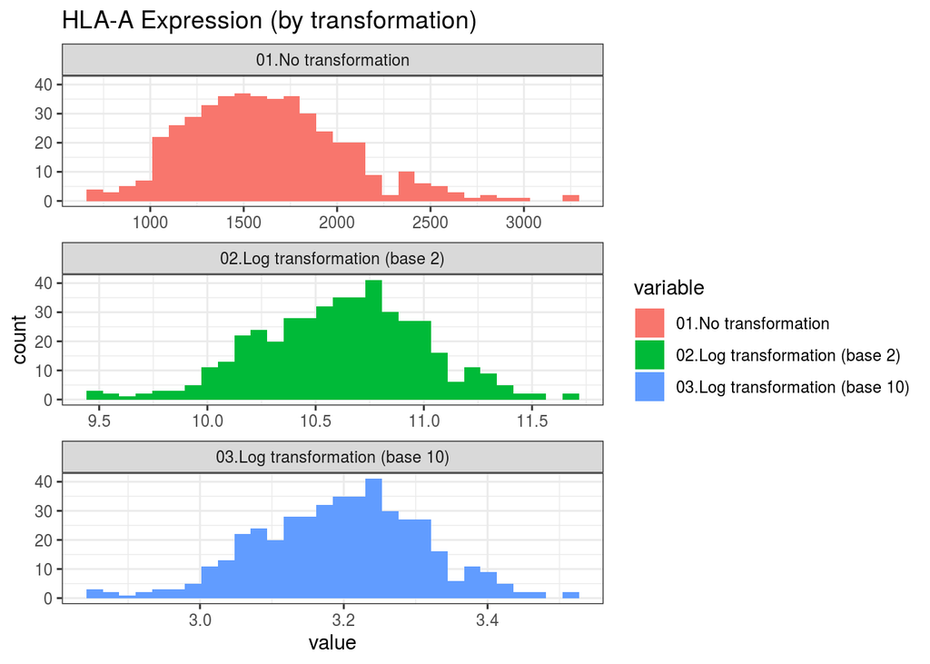

```r
p1[[1]]
```

```r
p1[[2]]
```

```
## geom_path: Each group consists of only one observation. Do you need to adjust
## the group aesthetic?
```

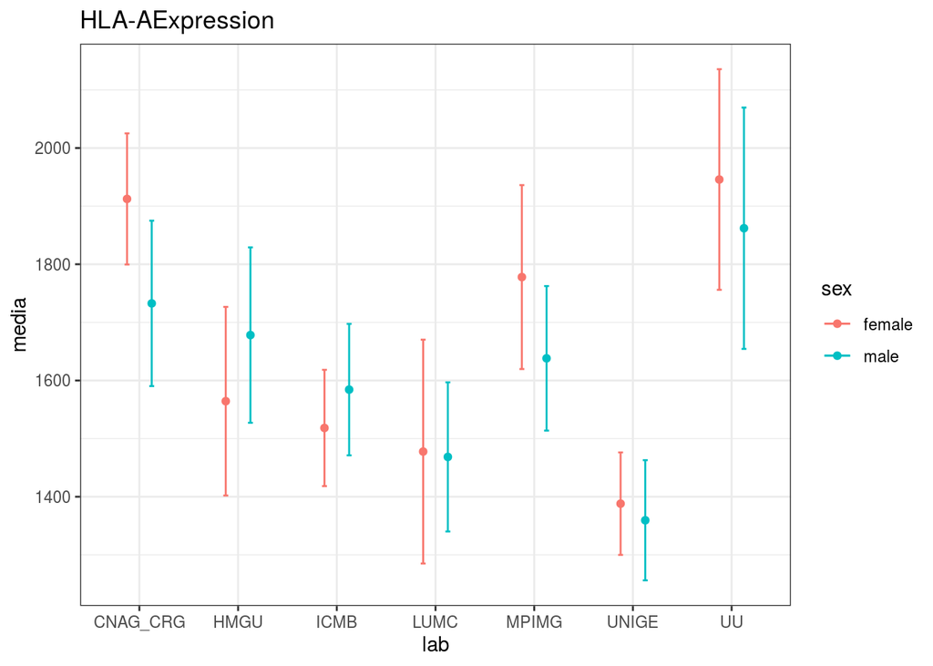

# Herdabilidade de HLA-B

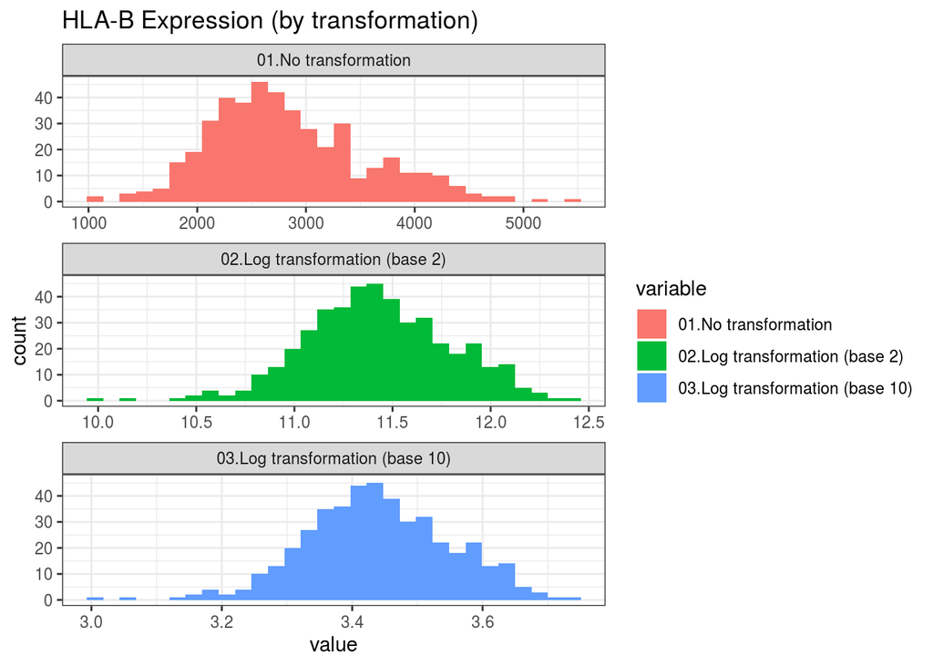

```r
p2[[1]]
```

```r
p2[[2]]
```

```
## geom_path: Each group consists of only one observation. Do you need to adjust
## the group aesthetic?
```

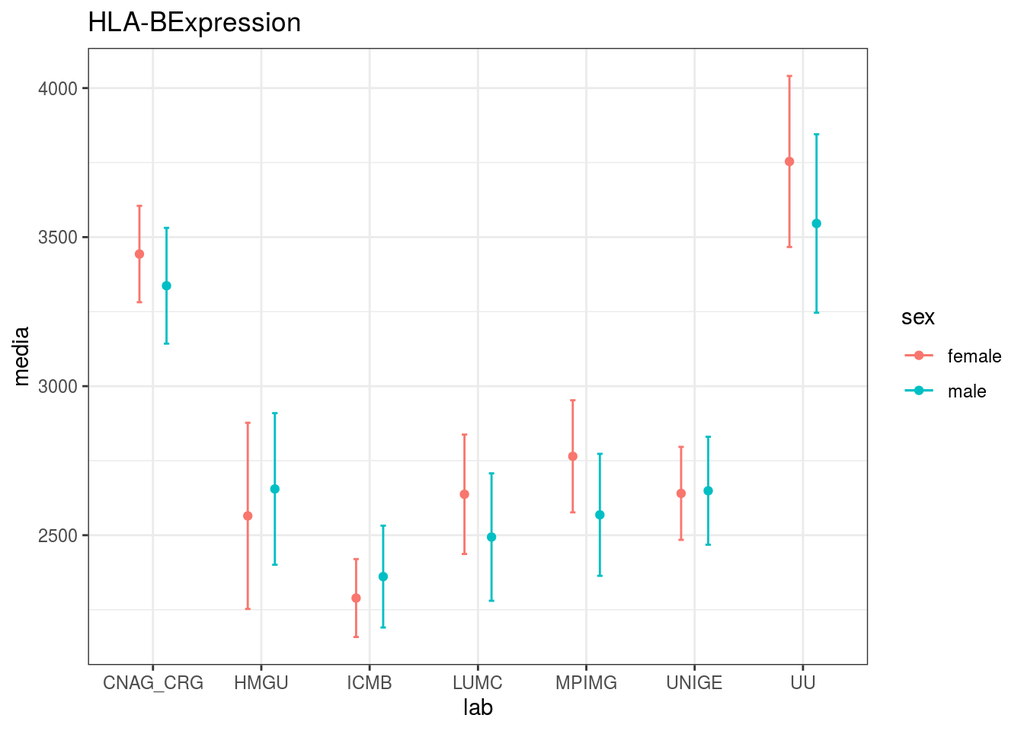

# Herdabilidade de HLA-C

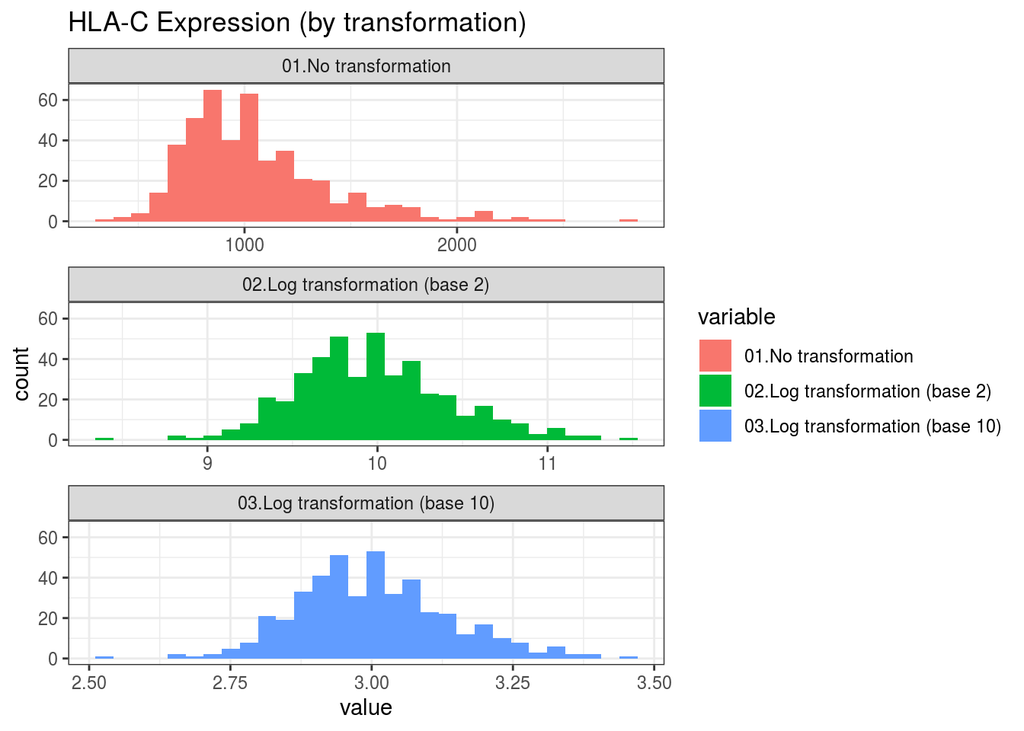

```r
p3[[1]]
```

```r
p3[[2]]
```

```
## geom_path: Each group consists of only one observation. Do you need to adjust
## the group aesthetic?
```

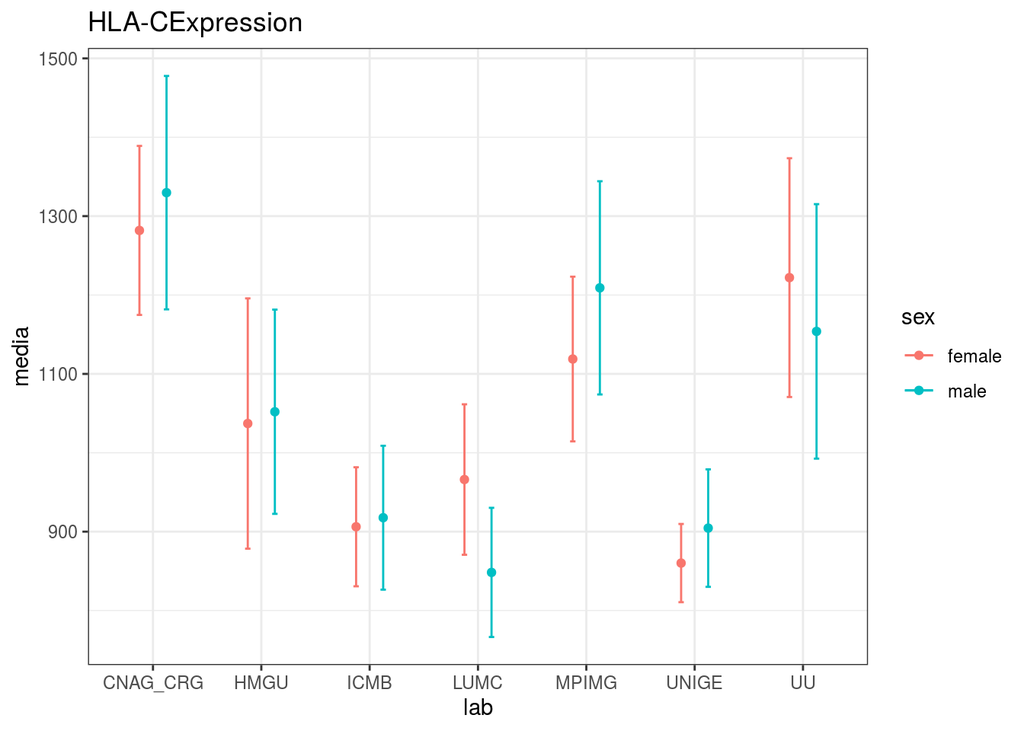

# Herdabilidade de HLA-DPA1

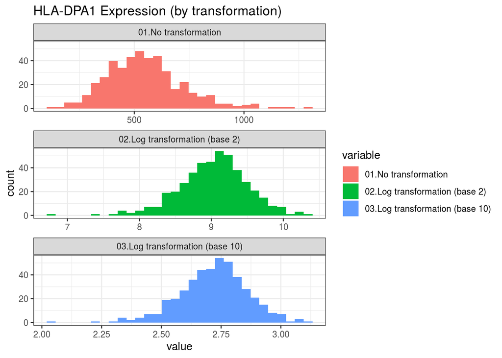

```r
p4[[1]]
```

```r
p4[[2]]
```

```
## geom_path: Each group consists of only one observation. Do you need to adjust
## the group aesthetic?
```

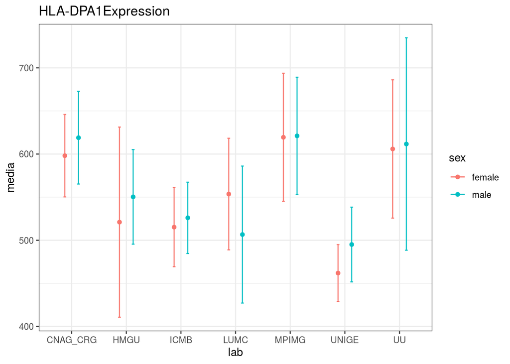

# Herdabilidade de HLA-DPB1

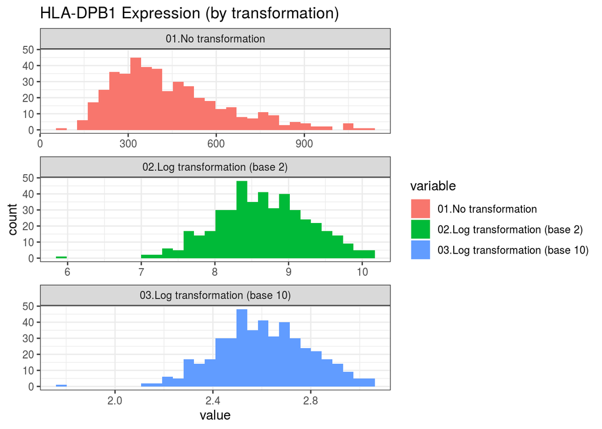

```r
p5[[1]]
```

```r
p5[[2]]
```

```
## geom_path: Each group consists of only one observation. Do you need to adjust
## the group aesthetic?
```

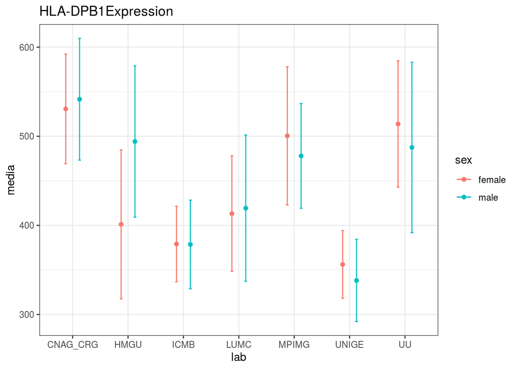

# Herdabilidade de HLA-DQA1

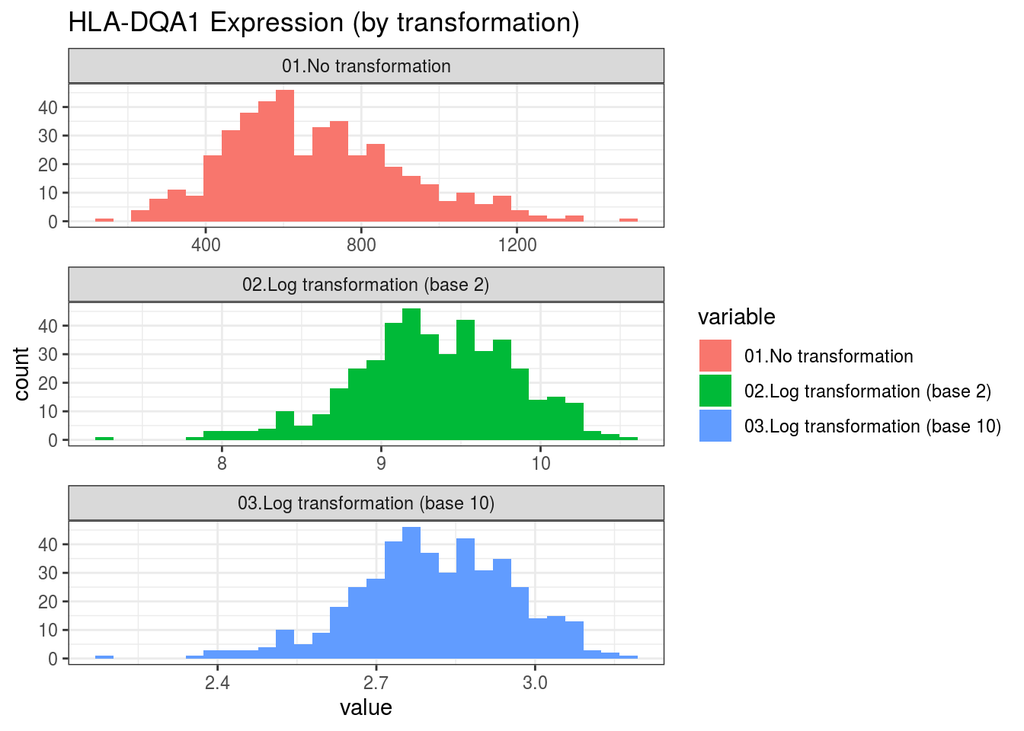

```r
p6[[1]]
```

```r
p6[[2]]
```

```
## geom_path: Each group consists of only one observation. Do you need to adjust
## the group aesthetic?
```

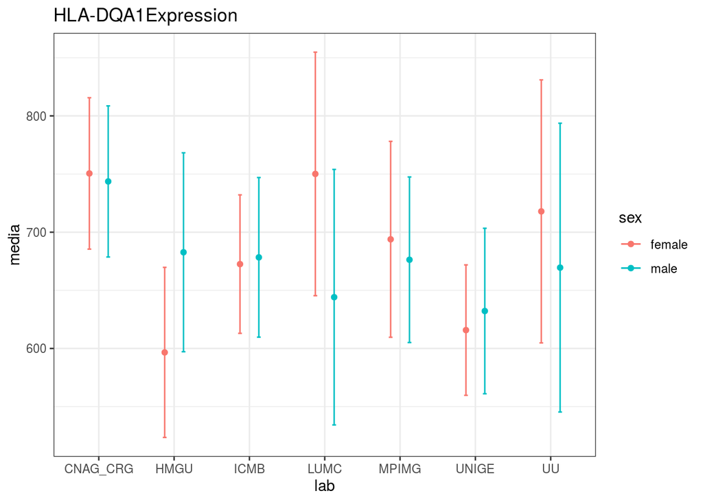

# Herdabilidade de HLA-DQB1

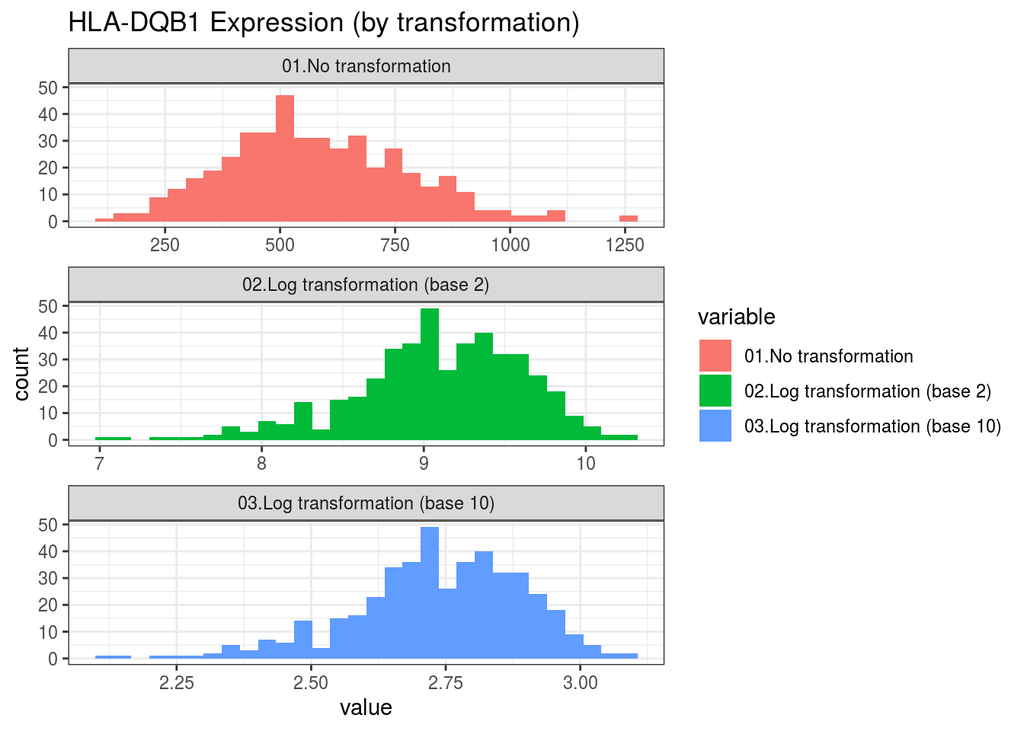

```r
p7[[1]]
```

```r
p7[[2]]
```

```
## geom_path: Each group consists of only one observation. Do you need to adjust
## the group aesthetic?
```

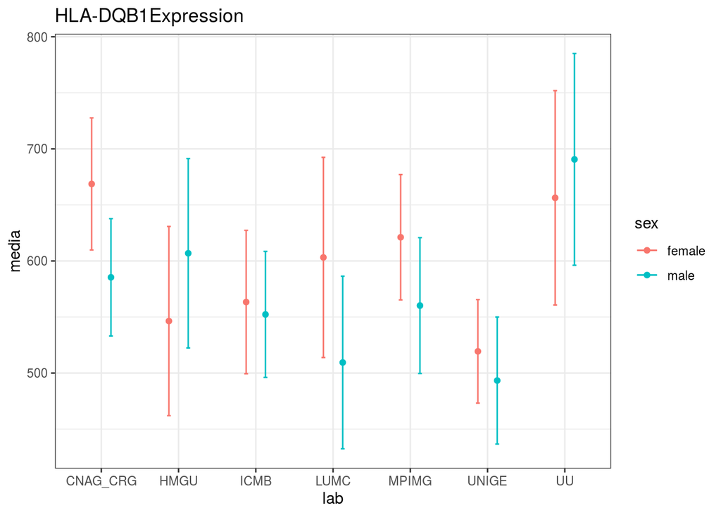

# Herdabilidade de HLA-DRA

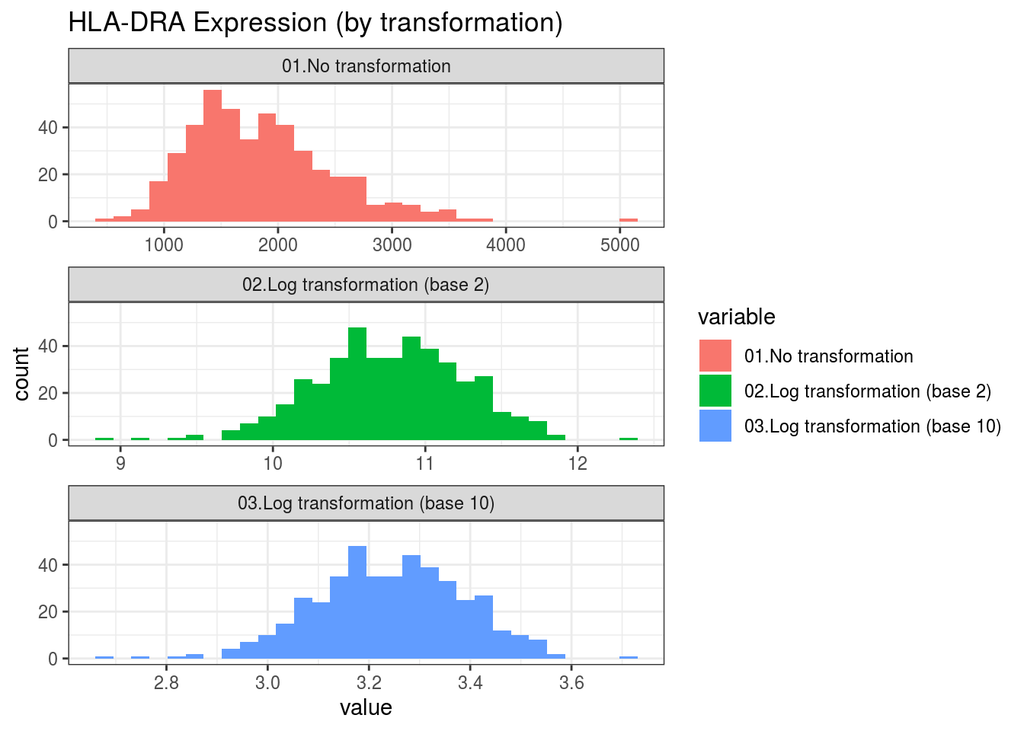

```r
p8[[1]]
```

```r
p8[[2]]
```

```
## geom_path: Each group consists of only one observation. Do you need to adjust
## the group aesthetic?
```

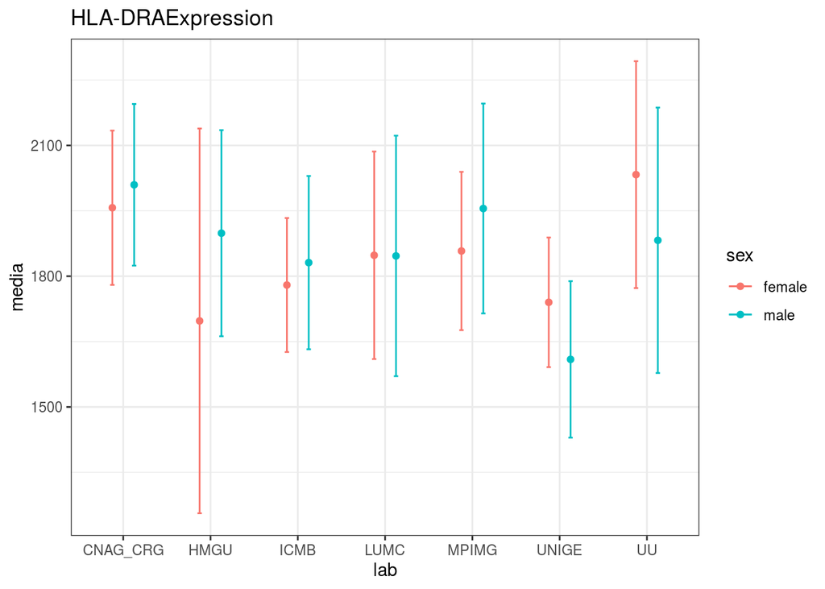

# Herdabilidade de HLA-DRB1

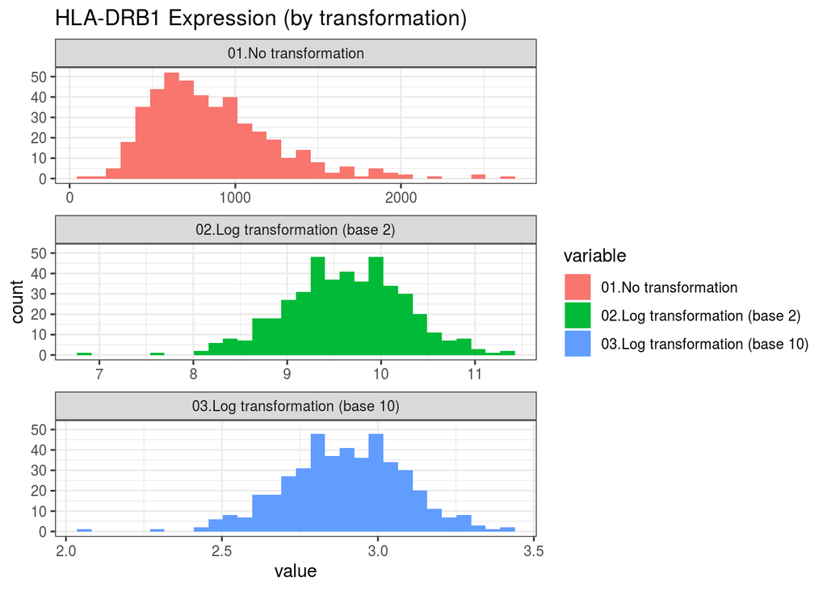

```r
p9[[1]]
```

```r
p9[[2]]
```

```
## geom_path: Each group consists of only one observation. Do you need to adjust
## the group aesthetic?
```

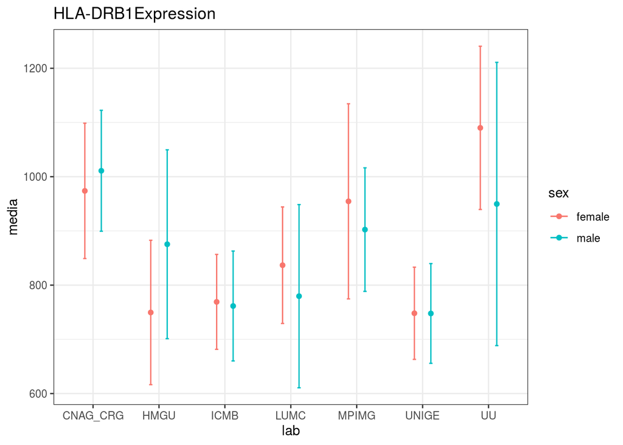

```r
descriptiveAnalisysGrm = function(version,nameMatrix,list){

    path = paste0("/scratch/genevol/users/lucas/V",version)
    readObj = readRDS( paste0(path , '/' , nameMatrix , '.rds') )
    GCTAMatrix = readObj$grm
    rownames(GCTAMatrix) = readObj$sample.id
    colnames(GCTAMatrix) = readObj$sample.id
    GCTAFilt = GCTAMatrix[list,list]
    return(GCTAFilt)

}
eigenDecomp = function(GRM,label_,pops_){

    eig = eigen(GRM)

    eigenValuesDf = cbind(eig$values,1:length(eig$values) ) %>% as.data.frame()
    colnames ( eigenValuesDf ) = c ( "eigen" , "order" )
    eigenValuesDf$cummulativeEigen = cumsum( eigenValuesDf$eigen ) / sum(eigenValuesDf$eigen)
    eigenValuesDf$flag = ifelse ( eigenValuesDf$eigen > mean(eigenValuesDf$eigen) , '>1' , '<=1' )
    eigenValuesDf$flag2 = ifelse ( eigenValuesDf$cummulativeEigen > .5 , '>1/2' , '<=1/2' )
    eigenValuesDf$label = label_

    pcadf <- as.data.frame(eig$vectors[,1:2]) %>%
    as_tibble() %>%
    mutate(sampleid = rownames(GRM) , label = label_) %>%
    inner_join(pops_, ., by = "sampleid")

    return(list(eigenValuesDf,pcadf))

}
# Lendo lista de individuos que conhecemos fenotipo


# Lendo a matriz GCTA ja previamente calculada
version = 1
kinshipV1Geuvadis = descriptiveAnalisysGrm(version,'GCTA_geuvadis',listGeuvadis$samples)

# Informacoes de PCA
pcaInfo = eigenDecomp(kinshipV1Geuvadis,'445 individuos, 412k snps',pops)
autoValores = pcaInfo[[1]]
print(autoValores[445,])
```

Correção da matriz GCTA

```r
# Methodology of Rebonato and Jackel (2000) to create a
# positive definite matrix out of a non-positive definite matrix.
# Reference: Rebonato and Jackel, "The most general methodology for
# creating a valid correlation matrix for risk management and
# option pricing purposes", Journal of Risk, Vol 2, No 2, 2000

fixNonPositiveDefiniteMatrix <- function(origMat) {
    cholStatus <- try(u <- chol(origMat), silent = TRUE)
    cholError <- ifelse(class(cholStatus) == "try-error", TRUE, FALSE)
    newMat <- origMat

    iter <- 0
    while (cholError) {

        iter <- iter + 1
        cat("iteration ", iter, "\n")

        # replace -ve eigen values with small +ve number
        newEig <- eigen(newMat)
        newEig2 <- ifelse(newEig$values < 0, 1e-10, newEig$values)

        # create modified matrix eqn 5 from Brissette et al 2007,
        # inv = transp for eig vectors
        newMat <- newEig$vectors %*% diag(newEig2) %*% t(newEig$vectors)

        # normalize modified matrix eqn 6 from Brissette et al 2007
        newMat <- newMat #/sqrt(diag(newMat) %*% t(diag(newMat)))

        # try chol again
        cholStatus <- try(u <- chol(newMat), silent = TRUE)
        cholError <- ifelse(class(cholStatus) == "try-error", TRUE, FALSE)
    }
    newMat
}

# randomCor, logico, se TRUE, cria as covariancias
# se FALSE, covariancias sao nulas.
blockDiagonalPDMatrix <- function(randomCor,...) {
  matrixList<-list(...)
  if(is.list(matrixList[[1]])) matrixList<-matrixList[[1]]

  dimensions<-sapply(matrixList,FUN=function(x) dim(x)[1])
  finalDimension<-sum(dimensions)

  finalMatrix<-matrix(0,nrow=finalDimension,ncol=finalDimension)
  if (randomCor == TRUE)
    finalMatrix <- rcorrmatrix(finalDimension, 1)

  index<-1
  for(k in 1:length(dimensions)){
    finalMatrix[index:(index+dimensions[k]-1),index:(index+dimensions[k]-1)]<-matrixList[[k]]
    index<-index+dimensions[k]
  }
  fixNonPositiveDefiniteMatrix(finalMatrix)
}
# Matriz corrigida
matrizCorrigida = suppressWarnings(fixNonPositiveDefiniteMatrix(kinshipV1Geuvadis))
matrizCorrigida[1:5,1:5]
rownames(matrizCorrigida) = rownames(kinshipV1Geuvadis)
colnames(matrizCorrigida) = colnames(kinshipV1Geuvadis)
```

# Herdabilidade de HLA-A

```r
hlaExp = readr::read_tsv("/raid/genevol/heritability/hla_expression.tsv")
ajustaModelo = function(hlaExpr , listSamples , gene_name_ , transf , vinit, matrizCor){
    filterGeneExpr = hlaExpr %>%
    filter(gene_name == gene_name_)

    if (transf == "log"){
        filterGeneExpr = filterGeneExpr %>% mutate(tpm = log(tpm))
    }

    fit_ = suppressWarnings(coxme::lmekin(filterGeneExpr$tpm ~ filterGeneExpr$lab + filterGeneExpr$sex, data=filterGeneExpr, random=~1|filterGeneExpr$subject_id, varlist=list(matrizCor), vinit=vinit))

    print(
        as.data.frame(fit_$residuals) %>% ggplot(aes(sample = fit_$residuals )) +
        stat_qq() +
        stat_qq_line() +
        theme_bw()
    )

    print(paste0("Teste de Shapiro para Normalidade: " , shapiro.test(fit_$residuals)$p.value))

    sig2eA <- fit_$sigma^2 ## Captura a variância do erro
    sig2gA <- as.numeric(fit_$vcoef) ## Captura a variância genética (poligênica)
    h <- sig2gA/(sig2gA+sig2eA) # Cálculo da herdabilidade

    if(h < 1 & !is.na(h) ){
        decompkmat<-eigen(matrizCor)$values  # decomposiçao espectral da matriz de parentesco
        ELRT <- -sum(log(1+h*(decompkmat-1)))
        # Valor-p
        p.value <- (1 - pchisq(ELRT, 1)) / 2
        paste0("valor-p: ",round(100*p.value,2),'%')
        return(list(fit_,h,p.value))
    } else{
        return(list(fit_))
    }

}
hla = ajustaModelo(hlaExpr = hlaExp, listSamples = listGeuvadis$samples , gene_name_ = 'HLA-A' , transf = "no" , vinit = 2, matrizCor = matrizCorrigida)
hla[[1]]
print(paste0("Herdabilidade estimada: " , round(hla[[2]] , 4) , " (valor-p " , round(hla[[3]] , 4),")"))
```

Transformação log da variável resposta - não foi possível de forma alguma (vinit = 0.1, 0.5 , 1 , 2 , 7.5 , 10 , 15 , 20 , 50 , 100 , 200 , 1000) Apenas sem transformação.

# Herdabilidade de HLA-B

```r
hla = ajustaModelo(hlaExpr = hlaExp, listSamples = listGeuvadis$samples , gene_name_ = 'HLA-B' , transf = "log" , vinit = 7.5, matrizCor = matrizCorrigida)
hla[[1]]
```

Com e sem transformação - não foi possível de forma alguma (vinit = 0.1, 0.5 , 1 , 2 , 7.5 , 10 , 15 , 20 , 50 , 100 , 200 , 1000)

# Herdabilidade de HLA-C

```r
hla = ajustaModelo(hlaExpr = hlaExp, listSamples = listGeuvadis$samples , gene_name_ = 'HLA-C' , transf = "no" , vinit = 1, matrizCor = matrizCorrigida)
hla[[1]]
print(paste0("Herdabilidade estimada: " , round(hla[[2]] , 4) , " (valor-p " , round(hla[[3]] , 4),")"))
```

Transformação log da variável resposta - não foi possível de forma alguma (vinit = 0.1, 0.5 , 1 , 2 , 7.5 , 10 , 15 , 20 , 50 , 100 , 200 , 1000) Apenas sem transformação.

# Herdabilidade de HLA-DPA1

```r
hla = ajustaModelo(hlaExpr = hlaExp, listSamples = listGeuvadis$samples , gene_name_ = 'HLA-DPA1' , transf = "no" , vinit = 1, matrizCor = matrizCorrigida)
hla[[1]]
print(paste0("Herdabilidade estimada: " , round(hla[[2]] , 4) , " (valor-p " , round(hla[[3]] , 4),")"))
```

É possível de se realizar o ajuste com transformação log (vinit = 2, 15 e 20) e sem transformação (vinit = 0.5, 1 , 2 e 15), mas em todos a herdabilidade é 1

# Herdabilidade de HLA-DPB1

```r
hla = ajustaModelo(hlaExpr = hlaExp, listSamples = listGeuvadis$samples , gene_name_ = 'HLA-DPB1' , transf = "no" , vinit = 20, matrizCor = matrizCorrigida)
hla[[1]]
print(paste0("Herdabilidade estimada: " , round(hla[[2]] , 4) , " (valor-p " , round(hla[[3]] , 4),")"))
```

É possível de se realizar o ajuste com transformação log (vinit = 200) e sem transformação (vinit = 20, 200), mas em todos a herdabilidade é 1

# Herdabilidade de HLA-DQA1

```r
hla = ajustaModelo(hlaExpr = hlaExp, listSamples = listGeuvadis$samples , gene_name_ = 'HLA-DQA1' , transf = "log" , vinit = 10, matrizCor = matrizCorrigida)
hla[[1]]
print(paste0("Herdabilidade estimada: " , round(hla[[2]] , 4) , " (valor-p " , round(hla[[3]] , 4),")"))
```

É possível de se realizar o ajuste com transformação log (vinit = 7.5, 10, 100) e sem transformação (vinit = 2, 20), mas em todos a herdabilidade é 1

# Herdabilidade de HLA-DQB1

```r
hla = ajustaModelo(hlaExpr = hlaExp, listSamples = listGeuvadis$samples , gene_name_ = 'HLA-DQB1' , transf = "no" , vinit = 100, matrizCor = matrizCorrigida)
hla[[1]]
print(paste0("Herdabilidade estimada: " , round(hla[[2]] , 4) , " (valor-p " , round(hla[[3]] , 4),")"))
```

É possível de se realizar o ajuste com transformação log (vinit = 20, 200) e sem transformação (vinit = 15, 100), mas em todos a herdabilidade é 1

# Herdabilidade de HLA-DRA

```r
hla = ajustaModelo(hlaExpr = hlaExp, listSamples = listGeuvadis$samples , gene_name_ = 'HLA-DRA' , transf = "log" , vinit = 20, matrizCor = matrizCorrigida)
hla[[1]]
print(paste0("Herdabilidade estimada: " , round(hla[[2]] , 4) , " (valor-p " , round(hla[[3]] , 4),")"))
```

É possível de se realizar o ajuste com transformação log (vinit = 15, 20) e sem transformação (vinit = 200), mas em todos a herdabilidade é 1

# Herdabilidade de HLA-DRB1

```r
hla = ajustaModelo(hlaExpr = hlaExp, listSamples = listGeuvadis$samples , gene_name_ = 'HLA-DRB1' , transf = "log" , vinit = 0.1, matrizCor = matrizCorrigida)
hla[[1]]
print(paste0("Herdabilidade estimada: " , round(hla[[2]] , 4) , " (valor-p " , round(hla[[3]] , 4),")"))
```

É possível de se realizar o ajuste com transformação log (vinit = 0.1, 200) e sem transformação (vinit = 0.1, 15, 100), mas em todos a herdabilidade é 1